# Statistics Mini Project : Customer Insights - A Staistical Investigation

## Phase 1 — Data Loading & Preview

```python
import pandas as pd
import numpy as np
import matplotlib.pyplot as plt
import seaborn as sns
import os
```

```python
os.getcwd()
```

```
'C:\\Users\\ariji'
```

```python
df = pd.read_csv("US_Customer_Insights_Dataset.csv")
```

```python
df.head()
```

|  | CustomerID | Name | State | Education | Gender | Age | Married | NumPets | JoinDate | TransactionDate | MonthlySpend | DaysSinceLastInteraction |
| --- | --- | --- | --- | --- | --- | --- | --- | --- | --- | --- | --- | --- |
| 0 | CUST10319 | Scott Perez | Florida | High School | Non-Binary | 47 | Yes | 1 | 9/19/21 | 9/2/24 | 1281.74 | 332 |
| 1 | CUST10695 | Jennifer Burton | Washington | Master | Male | 72 | Yes | 0 | 4/5/24 | 6/2/24 | 429.46 | 424 |
| 2 | CUST10297 | Michelle Rogers | Arizona | Master | Female | 40 | Yes | 2 | 7/24/24 | 2/28/25 | 510.34 | 153 |
| 3 | CUST10103 | Brooke Hendricks | Texas | Master | Male | 27 | Yes | 0 | 8/12/23 | 3/29/25 | 396.47 | 124 |
| 4 | CUST10219 | Karen Johns | Texas | High School | Female | 28 | Yes | 1 | 12/6/21 | 7/24/22 | 139.68 | 1103 |

```python
df.shape
```

```
(10675, 12)
```

```python
df.info()
```

```
<class 'pandas.core.frame.DataFrame'>
RangeIndex: 10675 entries, 0 to 10674
Data columns (total 12 columns):
 #   Column                    Non-Null Count  Dtype
---  ------                    --------------  -----
 0   CustomerID                10675 non-null  object
 1   Name                      10675 non-null  object
 2   State                     10675 non-null  object
 3   Education                 10675 non-null  object
 4   Gender                    10675 non-null  object
 5   Age                       10675 non-null  int64
 6   Married                   10675 non-null  object
 7   NumPets                   10675 non-null  int64
 8   JoinDate                  10675 non-null  object
 9   TransactionDate           10675 non-null  object
 10  MonthlySpend              10675 non-null  float64
 11  DaysSinceLastInteraction  10675 non-null  int64
dtypes: float64(1), int64(3), object(8)
memory usage: 1000.9+ KB
```

```python
df.dtypes
```

```
CustomerID                   object
Name                         object
State                        object
Education                    object
Gender                       object
Age                           int64
Married                      object
NumPets                       int64
JoinDate                     object
TransactionDate              object
MonthlySpend                float64
DaysSinceLastInteraction      int64
dtype: object
```

```python
df.nunique()
```

```
CustomerID                  1000
Name                         990
State                         10
Education                      5
Gender                         3
Age                           63
Married                        2
NumPets                        5
JoinDate                     731
TransactionDate             1605
MonthlySpend                9843
DaysSinceLastInteraction    1605
dtype: int64
```

### Doccumentation

- Loaded dataset using pd.read_csv() with a corrected Windows file path
- Previewed data using df.head(), df.shape, and df.info() and df.dtypes to get a understanding of the data to be analyzed.

## Phase 2 — Data Cleaning & Pre-Processing

```python
#checking for null values
df.isnull().sum()
```

```
CustomerID                  0
Name                        0
State                       0
Education                   0
Gender                      0
Age                         0
Married                     0
NumPets                     0
JoinDate                    0
TransactionDate             0
MonthlySpend                0
DaysSinceLastInteraction    0
dtype: int64
```

```python
df.duplicated().sum() # checking for duplicate data
```

```
np.int64(0)
```

```python
df.describe()  # understanding the numerical data
```

|  | Age | NumPets | MonthlySpend | DaysSinceLastInteraction |
| --- | --- | --- | --- | --- |
| count | 10675.000000 | 10675.000000 | 10675.000000 | 10675.000000 |
| mean | 49.474567 | 1.340515 | 331.610315 | 538.469883 |
| std | 18.221365 | 1.150849 | 225.799253 | 398.766747 |
| min | 18.000000 | 0.000000 | 3.890000 | 1.000000 |
| 25% | 35.000000 | 0.000000 | 165.495000 | 218.000000 |
| 50% | 49.000000 | 1.000000 | 282.110000 | 445.000000 |
| 75% | 66.000000 | 2.000000 | 443.255000 | 788.500000 |
| max | 80.000000 | 4.000000 | 1740.420000 | 1791.000000 |

```python
df['JoinDate'] = pd.to_datetime(df['JoinDate'], format='%m/%d/%y')
df['TransactionDate'] = pd.to_datetime(df['TransactionDate'], format='%m/%d/%y')
```

**Doccumentation :**

- Checked for missing values using df.isnull().sum() — no nulls found
- Checked for duplicates using df.duplicated().sum() — all rows unique
- Converted JoinDate and TransactionDate from object to datetime64 using pd.to_datetime() with format '%m/%d/%y'

## Phase 3 — Descriptive Statistics

```python
# perfroming descriptive stats on the data
round(df[['Age', 'MonthlySpend', 'DaysSinceLastInteraction']].agg(['mean', 'median', 'std']),2)
```

|  | Age | MonthlySpend | DaysSinceLastInteraction |
| --- | --- | --- | --- |
| mean | 49.47 | 331.61 | 538.47 |
| median | 49.00 | 282.11 | 445.00 |
| std | 18.22 | 225.80 | 398.77 |

```python
print(df['Gender'].mode()[0]) ## calculating mode for catagorical columns
print(df['Education'].mode()[0])
print(df['Married'].mode()[0])
```

```
Male
Master
No
```

### Doccumentation

- calculated mean, median and std dev for Age, MonthlySpend and DaysSinceLastInteraction using .agg()
- Age is normally distributed ,mean (49.47) and median (49.00) are nearly identical indicating no skew
- MonthlySpend is right skewed, mean (331.61) is higher than median (282.11) suggesting high-value outliers pulling the mean up
- DaysSinceLastInteraction has high std dev (398.77) indicating wide spread, customer interaction frequency varies significantly across the dataset
- Mode for categorical variables: most common customer profile is Male, Master's degree, Not Married.

## Phase 4 — Data Visualisation

### Age — Histogram & Boxplot

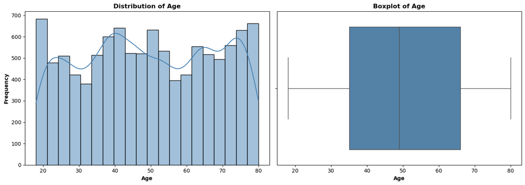

```python
fig, axes = plt.subplots(1, 2, figsize=(14, 5))

sns.histplot(df['Age'], bins=20, kde=True, color='steelblue', ax=axes[0])
axes[0].set_title('Distribution of Age',fontweight='bold')
axes[0].set_xlabel('Age',fontweight='bold')
axes[0].set_ylabel('Frequency',fontweight='bold')

sns.boxplot(x=df['Age'], color='steelblue', ax=axes[1])
axes[1].set_title('Boxplot of Age',fontweight='bold')
axes[1].set_xlabel('Age',fontweight='bold')

plt.tight_layout()
plt.show()
```

### Observations :

- Histogram shows a multimodal distribution with peaks around age 20, 40-50 and 70-80
- Distribution is largely symmetric which is further confirmed by mean (49.47) ≈ median (49.00)
- Boxplot shows median sitting at 49 with whiskers stretching equally from 20 to 80
- No outliers detected which tells us age data is clean and evenly spread.

### MonthlySpend — Histogram & Boxplot

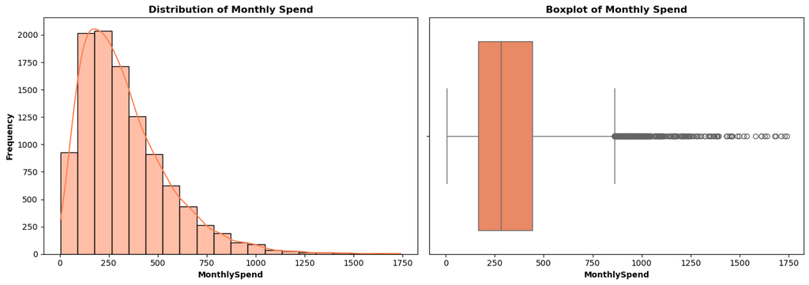

```python
fig, axes = plt.subplots(1, 2, figsize=(14, 5))
sns.histplot(df['MonthlySpend'], bins=20, kde=True, color='coral', ax=axes[0])
axes[0].set_title('Distribution of Monthly Spend',fontweight='bold')
axes[0].set_xlabel('MonthlySpend',fontweight='bold')
axes[0].set_ylabel('Frequency',fontweight='bold')

sns.boxplot(x=df['MonthlySpend'], color='coral', ax=axes[1])
axes[1].set_title('Boxplot of Monthly Spend',fontweight='bold')
axes[1].set_xlabel('MonthlySpend',fontweight='bold')

plt.tight_layout()
plt.show()
```

### Observations :

- Histogram shows a right skewed distribution with majority of customers spending between 100-300
- Long tail stretches towards higher values confirming presence of high spending customers
- Boxplot median sits at ~282 close to the left edge of the box which further confirms right skewness.
- Heavy outliers visible beyond the right whisker also consistent with mean (331.61) > median (282.11) observed in descriptive stats.

## Categorical Variable Distributions (Bar Charts)

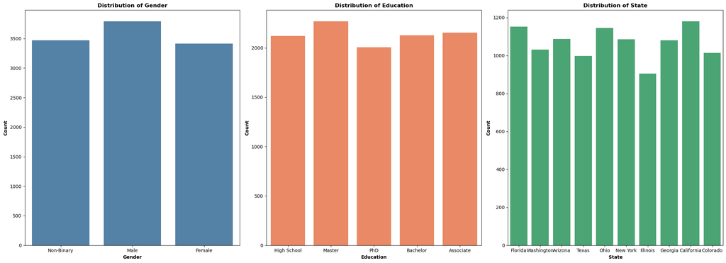

```python
fig, axes = plt.subplots(1, 3, figsize=(22, 8))

sns.countplot(x=df['Gender'], color='steelblue', ax=axes[0])
axes[0].set_title('Distribution of Gender',fontweight='bold')
axes[0].set_xlabel('Gender',fontweight='bold')
axes[0].set_ylabel('Count',fontweight='bold')

sns.countplot(x=df['Education'], color='coral', ax=axes[1])
axes[1].set_title('Distribution of Education',fontweight='bold')
axes[1].set_xlabel('Education',fontweight='bold')
axes[1].set_ylabel('Count',fontweight='bold')

sns.countplot(x=df['State'], color='mediumseagreen', ax=axes[2])
axes[2].set_title('Distribution of State',fontweight='bold')
axes[2].set_xlabel('State',fontweight='bold')
axes[2].set_ylabel('Count',fontweight='bold')

plt.tight_layout()
plt.show()
```

### Gender

- Male is the most dominant group but Non-Binary and Female counts are not far behind
- Distribution is fairly balanced across all three gender groups with no extreme skew

### Scatterplot [ Age vs Monthlyspend ] :

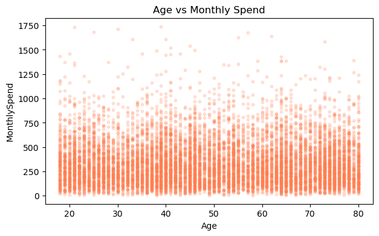

```python
plt.figure(figsize=(7,4))
plt.scatter(df['Age']
            , df['MonthlySpend'], alpha=0.2, s=10, color='coral')
plt.title('Age vs Monthly Spend')
plt.xlabel('Age')
plt.ylabel('MonthlySpend')
plt.show()
```

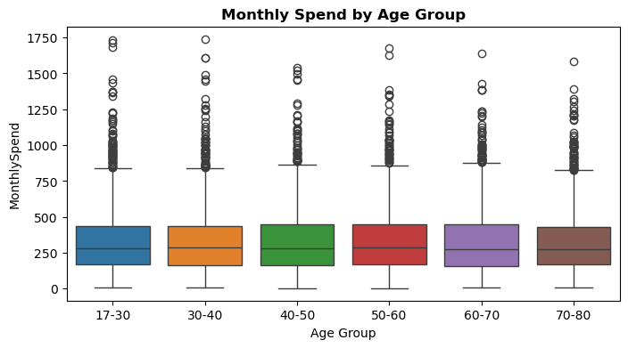

```python
df['AgeGroup'] = pd.cut(df['Age'], bins=[17,30,40,50,60,70,80],
                         labels=['17-30','30-40','40-50','50-60','60-70','70-80'])

plt.figure(figsize=(8,4))
sns.boxplot(x=df['AgeGroup'], y=df['MonthlySpend'], hue = df['AgeGroup'] ,legend = False)
plt.title('Monthly Spend by Age Group',fontweight='bold')
plt.xlabel('Age Group')
plt.ylabel('MonthlySpend')
plt.show()
```

### Observation :

**Age vs Monthly Spend with Scatter Plot & Box Plot**

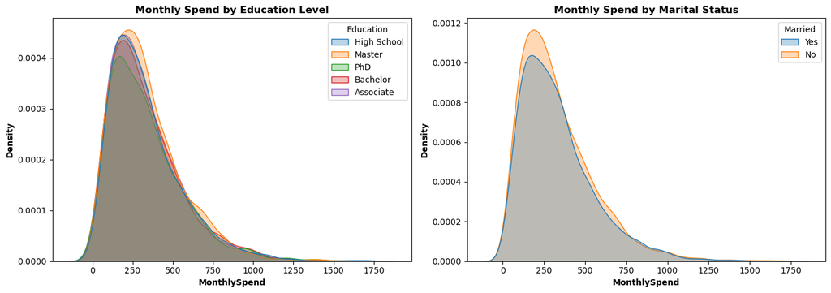

```python
fig, axes = plt.subplots(1, 2, figsize=(14, 5))

sns.kdeplot(data=df, x='MonthlySpend', hue='Education', fill=True, alpha=0.3, ax=axes[0])
axes[0].set_title('Monthly Spend by Education Level',fontweight="bold")
axes[0].set_xlabel('MonthlySpend',fontweight = 'bold')
axes[0].set_ylabel('Density',fontweight = 'bold')

sns.kdeplot(data=df, x='MonthlySpend', hue='Married', fill=True, alpha=0.3, ax=axes[1])
axes[1].set_title('Monthly Spend by Marital Status',fontweight ='bold')
axes[1].set_xlabel('MonthlySpend',fontweight ='bold')
axes[1].set_ylabel('Density',fontweight ='bold')

plt.tight_layout()
plt.show()
```

## Observations :

- Used sns.kdeplot() with hue parameter to compare MonthlySpend distributions across groups — no loops or subsets needed
- Education: All five education groups (High School, Master, PhD, Bachelor, Associate) show nearly identical spending distributions peaking around 200-- education level has no significant impact on MonthlySpend
- Marital Status: Married and Not Married customers show almost perfectly overlapping distributions we can presume marital status does not influence spending behaviour either
- Both plots confirm right skewed spending distributions consistent with what was found in earlier histogram and boxplot analysis Neither education level nor marital status are meaningful predictors of MonthlySpend also spending behaviour appears uniform across these demographic segments

## Phase 5 — Bivariate Analysis

```python
### Correlation Matrix for the numeric values
corr_matrix = df[['Age', 'MonthlySpend', 'DaysSinceLastInteraction']].corr()
corr_matrix
```

|  | Age | MonthlySpend | DaysSinceLastInteraction |
| --- | --- | --- | --- |
| Age | 1.000000 | -0.012323 | -0.003970 |
| MonthlySpend | -0.012323 | 1.000000 | 0.006081 |
| DaysSinceLastInteraction | -0.003970 | 0.006081 | 1.000000 |

**Bivariate Analysis with Correlation Matrix**

- Computed correlation matrix for Age, MonthlySpend, and DaysSinceLastInteraction using .corr()
- All correlation values are close to zero (-0.012 to 0.006) indicating no meaningful linear relationship between any pair of variables
- Customer age, spending and interaction recency do not influence each other — each variable should be analyzed and modeled independently
- creating a heatmap to understand this visualy

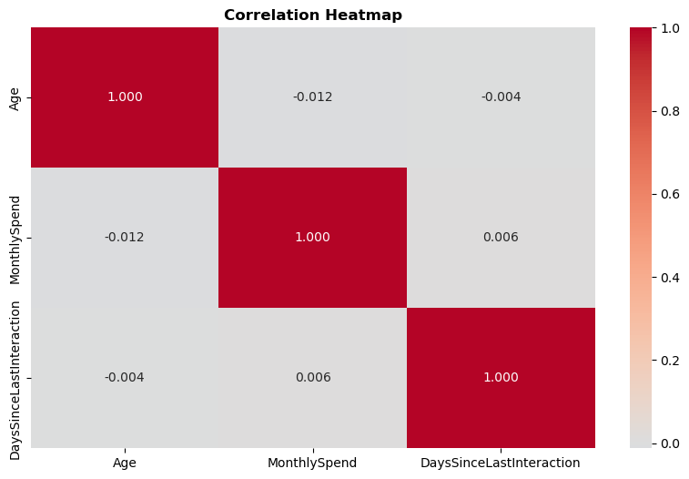

```python
plt.figure(figsize=(10,6))
sns.heatmap(corr_matrix, annot=True, cmap='coolwarm', center=0, fmt='.3f')
plt.title('Correlation Heatmap',fontweight = 'bold')
plt.show()
```

```python
### creating a cross tab of Gender vs Married
pd.crosstab(df['Gender'], df['Married'])
```

| Married Gender | No | Yes |
| --- | --- | --- |
| Female | 1797 | 1616 |
| Male | 1892 | 1899 |
| Non-Binary | 1894 | 1577 |

```python
# converting to percentage to undertand better
pd.crosstab(df['Gender'], df['Married'], normalize='index')
```

| Married Gender | No | Yes |
| --- | --- | --- |
| Female | 0.526516 | 0.473484 |
| Male | 0.499077 | 0.500923 |
| Non-Binary | 0.545664 | 0.454336 |

**Cross Tab: Gender vs Married**

- Created cross tabulation using pd.crosstab() to examine the relationship between Gender and Marital Status
- Male: Nearly perfect 50-50 split (49.9% Not Married vs 50.1% Married)
- Female: Slight lean towards Not Married (52.7% vs 47.3%), a modest 5.4% difference
- Non-Binary: Largest lean towards Not Married (54.6% vs 45.4%) a 9.2% difference, the most pronounced among the three groups
- over all Marital status is fairly evenly distributed across all gender groups with only minor variation and the relationship is statistically detectable, but practically irrelevant

```python
# grouped stats avergae Monthlyspend by Education , gender and State
print(df.groupby('State')['MonthlySpend'].mean().sort_values(ascending=False))
```

```
State
Arizona       341.489135
Ohio          340.187860
California    339.183492
Illinois      332.589591
New York      332.151244
Washington    329.444078
Georgia       328.354648
Florida       327.696892
Colorado      323.083462
Texas         319.506770
Name: MonthlySpend, dtype: float64
```

```python
print(df.groupby('Education')['MonthlySpend'].mean().sort_values(ascending=False))
```

```
Education
Master         334.252305
High School    332.215712
Bachelor       331.884753
PhD            331.690090
Associate      327.884408
Name: MonthlySpend, dtype: float64
```

```python
print(df.groupby('Gender')['MonthlySpend'].mean().sort_values(ascending=False))
```

```
Gender
Male          333.174068
Female        331.361310
Non-Binary    330.147240
Name: MonthlySpend, dtype: float64
```

**Average MonthlySpend by State, Education & Gender**

- Calculated grouped average MonthlySpend using .groupby() for State, Education, and Gender categories
- State: Averages range narrowly from 319.5 (Texas) to 341.5 (Arizona) found out no state shows significantly higher or lower spending
- Education: Averages range from 327.9 (Associate) to 334.3 (Master) shows minimal variation across education levels
- Gender: Averages range from 330.1 (Non-Binary) to 333.2 (Male) therefore virtually no difference across genders
- no demographic or geographic segment shows meaningfully higher or lower spending behaviour

## Phase 6 — Formulate Hypothesis

1. **Do males and females spend differently? (Independent t-test)**
- H₀: There is no significant difference in average MonthlySpend between Male and Female customers
- H₁: There is a significant difference in average MonthlySpend between Male and Female customers
2. **Does education level impact average monthly spend? (One-way ANOVA)**
- H₀: There is no significant difference in average MonthlySpend across different Education levels
- H₁: At least one Education level has a significantly different average MonthlySpend
3. **Are older people less active? (Correlation - Age vs DaysSinceLastInteraction)**
- H₀: There is no significant correlation between Age and DaysSinceLastInteraction
- H₁: There is a significant correlation between Age and DaysSinceLastInteraction
4. **Does state-wise spend vary significantly? (ANOVA)**
- H₀: There is no significant difference in average MonthlySpend across different States
- H₁: At least one State has a significantly different average MonthlySpend

## Phase 7 — Testing The Hypothesis

### **Do males and females spend differently? (Independent t-test)** :

- H₀: There is no significant difference in average MonthlySpend between Male and Female customers
- H₁: There is a significant difference in average MonthlySpend between Male and Female customers
- **Significance Level** : 0.05(α)

```python
from scipy import stats

male_spend = df[df['Gender'] == 'Male']['MonthlySpend']
female_spend = df[df['Gender'] == 'Female']['MonthlySpend']

t_stat, p_value = stats.ttest_ind(male_spend, female_spend)
print("T-statistic:", t_stat)
print("P-value:", p_value)
alpha = 0.05
if p_value < alpha:
    print("Reject the Null Hypothesis")
else:
    print("Fail to Reject the Null Hypothesis")
```

```
T-statistic: 0.3391730320232445
P-value: 0.7344892727022859
Fail to Reject the Null Hypothesis
```

**Since p-value (0.734) > α (0.05), we fail to reject the null hypothesis.**

### Observation :

**Independent T-Test (Gender vs MonthlySpend)**

- Performed stats.ttest_ind() on Male and Female MonthlySpend at α = 0.05
- Results: T-statistic = 0.339, P-value = 0.734
- Since p-value (0.734) > α (0.05), we fail to reject the null hypothesis
- Conclusion: No statistically significant difference in MonthlySpend between Male and Female customers.

### Does education level impact average monthly spend? (One-way ANOVA)

- H₀: There is no significant difference in average MonthlySpend across different Education levels
- H₁: At least one Education level has a significantly different average MonthlySpend

```python
groups = [df[df['Education'] == edu]['MonthlySpend'] for edu in df['Education'].unique()]

f_stat, p_value = stats.f_oneway(*groups)
print("F-statistic:", f_stat)
print("P-value:", p_value)

alpha = 0.05
if p_value < alpha:
    print("Reject the Null Hypothesis: At least one Education level has a significantly different average MonthlySpend")
else:
    print("Fail to Reject the Null Hypothesis: No significant difference in average MonthlySpend across Education levels")
```

```
F-statistic: 0.22880668673709165
P-value: 0.922359467759936
Fail to Reject the Null Hypothesis: No significant difference in average MonthlySpend across Education levels
```

### Observations :

**One-Way ANOVA (Education vs MonthlySpend)**

- Performed stats.f_oneway() across all Education groups at α = 0.05
- Results: F-statistic = 0.229, P-value = 0.922
- Since p-value (0.922) > α (0.05), we fail to reject the null hypothesis
- Conclusion: No statistically significant difference in MonthlySpend across Education levels

### Are older people less active? (Correlation - Age vs DaysSinceLastInteraction)

- H₀: There is no significant correlation between Age and DaysSinceLastInteraction
- H₁: There is a significant correlation between Age and DaysSinceLastInteraction

```python
#correlation
corr_coef, p_value = stats.pearsonr(df['Age'], df['DaysSinceLastInteraction'])
print("Correlation coefficient:", corr_coef)
print("P-value:", p_value)

alpha = 0.05
if p_value < alpha:
    print("Reject the Null Hypothesis: There is a significant correlation between Age and DaysSinceLastInteraction")
else:
    print("Fail to Reject the Null Hypothesis: No significant correlation between Age and DaysSinceLastInteraction")
```

```
Correlation coefficient: -0.003970230104955046
P-value: 0.6816905437300954
Fail to Reject the Null Hypothesis: No significant correlation between Age and DaysSinceLastInteraction
```

### Observations :

**Pearson Correlation (Age vs DaysSinceLastInteraction)**

- Performed stats.pearsonr() at α = 0.05
- Results: Correlation coefficient = -0.004, P-value = 0.682
- Since p-value (0.682) > α (0.05), we fail to reject the null hypothesis
- Conclusion: No statistically significant correlation between Age and DaysSinceLastInteraction, we can say that older customers are not necessarily less active, consistent with the near-zero value seen earlier in the correlation matrix.

### Does state-wise spend vary significantly? (ANOVA)

- H₀: There is no significant difference in average MonthlySpend across different States
- H₁: At least one State has a significantly different average MonthlySpend

```python
#Anova test
state_groups = []
for state in df['State'].unique():
    state_groups.append(df[df['State'] == state]['MonthlySpend'])

f_stat, p_value = stats.f_oneway(*state_groups)
print("F-statistic:", f_stat)
print("P-value:", p_value)

alpha = 0.05
if p_value < alpha:
    print("Reject the Null Hypothesis: At least one State has a significantly different average MonthlySpend")
else:
    print("Fail to Reject the Null Hypothesis: No significant difference in average MonthlySpend across States")
```

```
F-statistic: 1.1178423640877182
P-value: 0.34571886479238273
Fail to Reject the Null Hypothesis: No significant difference in average MonthlySpend across States
```

### Observations :

Inferential Statistics — One-Way **ANOVA (State vs MonthlySpend)**

- Performed stats.f_oneway() across all State groups at α = 0.05
- Results: F-statistic = 1.118, P-value = 0.346
- Since p-value (0.346) > α (0.05), we fail to reject the null hypothesis
- Conclusion: No statistically significant difference in MonthlySpend across States.

### Summary :

This project analyzed the US_Customer_Insights_Dataset.csv through a complete statistical workflow, starting with data loading and cleaning, moving through descriptive statistics and visualizations, into bivariate analysis, and finishing with formal inferential hypothesis testing. The dataset was clean (no nulls, no duplicates) and well-structured, allowing focus to stay on the analysis.

## Key Business Insights

**Key findings from the customer data analysis**

**Demographic Independence of Spending**

- One of the biggest takeaways is that traditional demographics just don't predict how much people spend. Whether we’re looking at gender, education, or state, the spending patterns are effectively the same across the board (all with p-values > 0.05). If we’ve been spending time trying to segment our pricing or marketing based on these traits, we’re likely not getting much return on that effort.
- **Focusing on the Big Spenders** While most of our customers fall in the $100–$300 range, we have a consistent group of "power users" who spend significantly more. The catch is that they aren't tied to any specific demographic—they’re scattered everywhere. Instead of segmenting by background, I think we’d get much better results by identifying these high-value individuals and building a specific strategy to keep them engaged.

**Age isn't a factor**

- I looked into whether age affects how much people spend or how often they check in with us, and the numbers are essentially flat (-0.012 and -0.004). We should probably stop using age as a filter for our engagement strategies; it’s just not telling us anything useful about how they behave.

**Engagement Variability and Future Research**

- The biggest question mark in the data is why some customers haven't interacted with us in a long time. The variance here is massive (an average swing of about 399 days), and since demographics don't explain it, we’re looking at something else—maybe the product type, support history, or the channel they came in through. We need to look deeper into the service or product side of things to figure out why we’re losing touch.

**Business Impact**

- Overall, our customer base is pretty healthy and balanced. We don’t have one group dominating the data, though we do have a slight tilt toward Florida/California residents and those with Master’s degrees. It’s a diverse group, which actually gives us a lot of room to experiment with new strategies that don’t rely on old-school demographics